# Assignment 2

## Machine Learning Techniques

**Completed By**: Justin Marchioni

**Date**: Mar. 13$^\textrm{th}$, 2024

This assignment is split into 3 sections, roughly corresponding to the contents of each of the 3 weeks in the Machine Learning module.

All assignments are presented as Jupyter notebooks. You will fork the repository to have your own access to all files. You can edit this notebook directly with your answers and push your changes to GitHub.

### **The goal of this assignment is to use different ML techniques to explore your data, find patterns in it, and eventually build a model that will allow us to predict stellar mass & redshift of galaxies *without doing SED fitting*.**

# Section 0: Data Preprocessing

Before we delve into machine learning, it's a good idea to look at our data, pick which sample we want to work with, etc.

The code below loads in the input data catalog:

```python
from astropy.table import Table
from astropy.io import fits
import numpy as np
import matplotlib.colors as mcolors
import matplotlib.pyplot as plt
import pandas as pd
import scipy.stats as stats

with fits.open('../data/sw_input.fits') as f:
    df = Table(f[1].data).to_pandas()
    f.close()

# Display the top 3 rows of the dataframe
df.head(3)
```

|  | id | ra | dec | redshift | PLATE | MJD | FIBERID | designation | flux0_u | flux0_u_e | ... | flux_w2_e | flux_w3 | flux_w3_e | flux_w4 | flux_w4_e | extin_u | extin_g | extin_r | extin_i | extin_z |
| --- | --- | --- | --- | --- | --- | --- | --- | --- | --- | --- | --- | --- | --- | --- | --- | --- | --- | --- | --- | --- | --- |
| 0 | 3 | 337.450310 | 1.266134 | 0.088372 | 376 | 52143 | 404 | J222948.07+011558.1 | 0.000031 | 0.000003 | ... | 0.000049 | 4.172000e-07 | 0.000209 | 0.000002 | 0.001187 | 0.341327 | 0.265960 | 0.183990 | 0.136724 | 0.101698 |
| 1 | 5 | 338.115522 | 1.270146 | 0.163800 | 376 | 52143 | 567 | J223227.69+011612.6 | 0.000011 | 0.000004 | ... | 0.000111 | 9.851000e-07 | 0.000493 | 0.000004 | 0.001883 | 0.368063 | 0.286793 | 0.198402 | 0.147434 | 0.109664 |
| 2 | 8 | 341.101481 | 1.266255 | 0.143369 | 378 | 52146 | 404 | J224424.38+011558.3 | 0.000017 | 0.000003 | ... | 0.000039 | 1.013700e-06 | 0.000507 | 0.000008 | 0.003856 | 0.337630 | 0.263079 | 0.181997 | 0.135243 | 0.100596 |

3 rows × 49 columns

#### Question 1

Look at all the column names. Choose which columns have *meaningful* data, i.e. have data we want to use in our machine learning to predict stellar mass and/or redshift. Why did you choose these ones?

```python
# Extract the columns from the data table
columns = df.columns

# Choose the useful columns
pick = [0, 26, 27, 28, 29, 30, 31, 32, 33, 34, 35, 36, 37, 38, 39, 40, 41, 42, 43]
columns = columns[pick]

# Display the useful columns
print(columns)
```

```
Index(['id', 'flux_u', 'flux_u_e', 'flux_g', 'flux_g_e', 'flux_r', 'flux_r_e',
       'flux_i', 'flux_i_e', 'flux_z', 'flux_z_e', 'flux_w1', 'flux_w1_e',
       'flux_w2', 'flux_w2_e', 'flux_w3', 'flux_w3_e', 'flux_w4', 'flux_w4_e'],
      dtype='object')
```

The columns from the input data table that have meaningful data are displayed above, excluding the first column showing the ID of the galaxy. This is just used to match galaxies between the input and output catalogues. The data we have selected is of one primary type:

1. Fluxes/Errors: These are the measured fluxes and their errors in 9 bands, after galatic extinction corrections. These are the primary measurements used in SED fitting to construct a model for each galaxy, so these should be included in our analysis as well.

There are a few columns that we ignore.

1. Galaxy Positions
2. Redshift
3. Fluxes/Errors without corrections
4. Galactic extinction corrections

We do not select galaxy positions (RA and DEC) since the Universe is homogeneous and isotropic, so the properties of galaxies should not vary between different survey areas. We do not select the redshift since this may be a parameter we want our model to predict. This would result in overfitting if we were to include spectroscopic redshifts in training our model to predict redshifts. We do not select the fluxes and errors without galactic extinction corrections, as well as the extinction corrections themselves, since this information should be encoded in the corrected fluxes/errors.

#### Question 2

Choose a reasonably-sized subset of your data ($10^3 \sim 10^4$ or so galaxies)  
Make sure to save your subset, or at least the IDs you choose, for later - you will need them!

```python
# Set a seed so that we obtain the same random sample each time
np.random.seed(20726114)

# Select a random sample of galaxies from the input dataframe
# Note: These are filtered for the desired columns
sample = df.sample(8000)[columns]

# Add in a first column that stores the index of the table itself
sample.insert(0, 'table_id', sample.index.to_list())

# Convert the sample to a table
t = Table.from_pandas(sample)

# Save the sample as a .fits file for later use
fname = '../data/A2 Sample.fits'
t.write(fname, format = 'fits', overwrite = True)
```

```python
# Read in the sample to check
with fits.open('../data/A2 Sample.fits') as f:
    sp = Table(f[1].data).to_pandas()
    f.close()

display(sp)
```

|  | table_id | id | flux_u | flux_u_e | flux_g | flux_g_e | flux_r | flux_r_e | flux_i | flux_i_e | flux_z | flux_z_e | flux_w1 | flux_w1_e | flux_w2 | flux_w2_e | flux_w3 | flux_w3_e | flux_w4 | flux_w4_e |
| --- | --- | --- | --- | --- | --- | --- | --- | --- | --- | --- | --- | --- | --- | --- | --- | --- | --- | --- | --- | --- |
| 0 | 735620 | 2209771 | 0.000098 | 0.000007 | 0.000343 | 1.713300e-05 | 0.000676 | 0.000034 | 0.000972 | 0.000049 | 0.001267 | 0.000063 | 0.000841 | 0.000117 | 0.000551 | 0.000078 | 2.256990e-03 | 0.000291 | 0.005500 | 0.001325 |
| 1 | 345591 | 1036173 | 0.000019 | 0.000003 | 0.000101 | 5.033200e-06 | 0.000291 | 0.000015 | 0.000452 | 0.000023 | 0.000634 | 0.000032 | 0.000678 | 0.000090 | 0.000475 | 0.000064 | 9.432430e-04 | 0.000179 | 0.005460 | 0.001202 |
| 2 | 827643 | 2382326 | 0.000093 | 0.000008 | 0.000272 | 1.360480e-05 | 0.000490 | 0.000024 | 0.000676 | 0.000034 | 0.000876 | 0.000044 | 0.000602 | 0.000094 | 0.000397 | 0.000063 | 1.425780e-03 | 0.000209 | 0.000003 | 0.001489 |
| 3 | 711375 | 2021907 | 0.000075 | 0.000005 | 0.000261 | 1.303700e-05 | 0.000491 | 0.000025 | 0.000701 | 0.000035 | 0.000895 | 0.000045 | 0.000742 | 0.000094 | 0.000470 | 0.000060 | 1.899620e-03 | 0.000185 | 0.003637 | 0.000892 |
| 4 | 21112 | 79066 | 0.000159 | 0.000011 | 0.000390 | 1.947630e-05 | 0.000658 | 0.000033 | 0.000891 | 0.000045 | 0.001033 | 0.000052 | 0.000759 | 0.000109 | 0.000578 | 0.000085 | 4.153810e-03 | 0.000515 | 0.003067 | 0.001553 |
| ... | ... | ... | ... | ... | ... | ... | ... | ... | ... | ... | ... | ... | ... | ... | ... | ... | ... | ... | ... | ... |
| 7995 | 559295 | 1699196 | 0.000003 | 0.000003 | 0.000010 | 9.750000e-07 | 0.000051 | 0.000003 | 0.000116 | 0.000006 | 0.000186 | 0.000010 | 0.000474 | 0.000068 | 0.000291 | 0.000043 | 7.415000e-07 | 0.000371 | 0.000004 | 0.002147 |
| 7996 | 572543 | 1728789 | 0.000037 | 0.000004 | 0.000172 | 8.595000e-06 | 0.000393 | 0.000020 | 0.000559 | 0.000028 | 0.000719 | 0.000036 | 0.000460 | 0.000053 | 0.000292 | 0.000035 | 2.841000e-07 | 0.000142 | 0.000003 | 0.001276 |
| 7997 | 515893 | 1400962 | 0.000047 | 0.000004 | 0.000255 | 1.273950e-05 | 0.000584 | 0.000029 | 0.000842 | 0.000042 | 0.001159 | 0.000058 | 0.000768 | 0.000102 | 0.000443 | 0.000060 | 2.188000e-07 | 0.000109 | 0.000002 | 0.000853 |
| 7998 | 90941 | 313393 | 0.000102 | 0.000009 | 0.000511 | 2.555710e-05 | 0.001284 | 0.000064 | 0.001897 | 0.000095 | 0.002639 | 0.000132 | 0.002583 | 0.000408 | 0.001705 | 0.000270 | 2.296110e-03 | 0.000363 | 0.000003 | 0.001640 |
| 7999 | 734102 | 2206750 | 0.000052 | 0.000005 | 0.000223 | 1.116120e-05 | 0.000489 | 0.000024 | 0.000725 | 0.000036 | 0.000969 | 0.000048 | 0.000819 | 0.000115 | 0.000547 | 0.000078 | 1.256370e-03 | 0.000219 | 0.000002 | 0.001144 |

8000 rows × 20 columns

#### Question 3

It is often useful (and sometimes required) to *normalize* your data, i.e. for each parameter, subtract the mean of that parameter from each point in the sample, and divide by the standard deviation. For example, for mass, for each galaxy $i$, you can calculate

$$ M_{norm, i} = \frac{M_i - \langle M \rangle}{\sigma_M}$$

There are other ways to pre-process data (e.g., normalize by quantiles, or redefine variables such that they match some distribution).

- For each column you chose, normalize the data in your sample in some way.
- For one parameter, make a histogram of the original data, and the data after normalization. Do the histograms look as you expected them to?

```python
# Define a function to calculated the normalized quantity
# for a parameter in the table
# Note: These are normalized by calculating the z-score as
#       defined above
def Normalize(table, col):

    # Extract the data for a given column
    X = table[col].values.T

    # Calculate the mean and standard deviation for the sample
    X_mean = np.mean(X)
    X_std = np.sqrt(np.var(X, ddof = 1))

    # Return the z-score
    return (X - X_mean) / X_std, X_mean, X_std

# End of function definition
```

```python
# Create a copy of the sample table
sp_norm = sp.copy()

# Get the columns of the sample table
columns = sp_norm.columns

# Remove the first two columns from our list
col_sel = columns[2:]

# Store the mean and variance for each sample
S_mean = np.zeros(len(col_sel))
S_std = np.zeros(len(col_sel))

# Loop over each selected column
for i in range(0, len(col_sel)):

    # Update the data in the table with the normalized version
    (sp_norm[col_sel[i]], S_mean[i], S_std[i]) = Normalize(sp_norm, col_sel[i])

# End of for loop

# Convert the sample to a table
t = Table.from_pandas(sp_norm)

# Save the normalized sample as a .fits file for later use
fname = '../data/A2 Sample (Norm).fits'
t.write(fname, format = 'fits', overwrite = True)
```

```python
# Read in the normalized sample to check
with fits.open('../data/A2 Sample (Norm).fits') as f:
    sp_norm = Table(f[1].data).to_pandas()
    f.close()

display(sp_norm)
```

|  | table_id | id | flux_u | flux_u_e | flux_g | flux_g_e | flux_r | flux_r_e | flux_i | flux_i_e | flux_z | flux_z_e | flux_w1 | flux_w1_e | flux_w2 | flux_w2_e | flux_w3 | flux_w3_e | flux_w4 | flux_w4_e |
| --- | --- | --- | --- | --- | --- | --- | --- | --- | --- | --- | --- | --- | --- | --- | --- | --- | --- | --- | --- | --- |
| 0 | 735620 | 2209771 | 0.029910 | -0.040465 | -0.008211 | -0.020223 | -0.035987 | -0.039577 | -0.036806 | -0.038753 | -0.043041 | -0.046112 | -0.122648 | -0.122398 | -0.120947 | -0.120790 | -0.120936 | -0.121326 | -0.117777 | -0.120772 |
| 1 | 345591 | 1036173 | -0.378633 | -0.340044 | -0.331139 | -0.303348 | -0.291144 | -0.282060 | -0.279648 | -0.276330 | -0.269111 | -0.270094 | -0.122783 | -0.122420 | -0.121011 | -0.120802 | -0.122035 | -0.121420 | -0.117811 | -0.120875 |
| 2 | 827643 | 2382326 | 0.002396 | 0.046959 | -0.102375 | -0.102780 | -0.159748 | -0.157190 | -0.175143 | -0.174092 | -0.182765 | -0.184546 | -0.122846 | -0.122417 | -0.121077 | -0.120803 | -0.121631 | -0.121395 | -0.122396 | -0.120634 |
| 3 | 711375 | 2021907 | -0.090862 | -0.199470 | -0.117529 | -0.116066 | -0.159080 | -0.156555 | -0.163248 | -0.162453 | -0.175927 | -0.177771 | -0.122730 | -0.122417 | -0.121016 | -0.120805 | -0.121235 | -0.121414 | -0.119343 | -0.121136 |
| 4 | 21112 | 79066 | 0.345608 | 0.273465 | 0.054328 | 0.034608 | -0.047943 | -0.050938 | -0.074423 | -0.075554 | -0.126533 | -0.128832 | -0.122716 | -0.122404 | -0.120925 | -0.120784 | -0.119349 | -0.121139 | -0.119821 | -0.120580 |
| ... | ... | ... | ... | ... | ... | ... | ... | ... | ... | ... | ... | ... | ... | ... | ... | ... | ... | ... | ... | ... |
| 7995 | 559295 | 1699196 | -0.464146 | -0.386518 | -0.452038 | -0.398306 | -0.450604 | -0.433598 | -0.436729 | -0.430007 | -0.429317 | -0.426687 | -0.122952 | -0.122439 | -0.121166 | -0.120819 | -0.122824 | -0.121259 | -0.122395 | -0.120082 |
| 7996 | 572543 | 1728789 | -0.285206 | -0.248647 | -0.236079 | -0.220005 | -0.223579 | -0.217851 | -0.229714 | -0.227480 | -0.238607 | -0.239872 | -0.122964 | -0.122451 | -0.121166 | -0.120826 | -0.122824 | -0.121450 | -0.122397 | -0.120814 |
| 7997 | 515893 | 1400962 | -0.234594 | -0.299687 | -0.125467 | -0.123027 | -0.097152 | -0.097704 | -0.097646 | -0.098274 | -0.081390 | -0.084108 | -0.122708 | -0.122411 | -0.121038 | -0.120806 | -0.122824 | -0.121478 | -0.122397 | -0.121169 |
| 7998 | 90941 | 313393 | 0.053121 | 0.160562 | 0.216614 | 0.176893 | 0.367246 | 0.343625 | 0.395308 | 0.383991 | 0.447578 | 0.439982 | -0.121202 | -0.122156 | -0.119978 | -0.120629 | -0.120903 | -0.121265 | -0.122396 | -0.120507 |
| 7999 | 734102 | 2206750 | -0.211208 | -0.186306 | -0.167589 | -0.159958 | -0.159796 | -0.157236 | -0.152379 | -0.151820 | -0.149422 | -0.151510 | -0.122666 | -0.122399 | -0.120951 | -0.120790 | -0.121773 | -0.121386 | -0.122397 | -0.120924 |

8000 rows × 20 columns

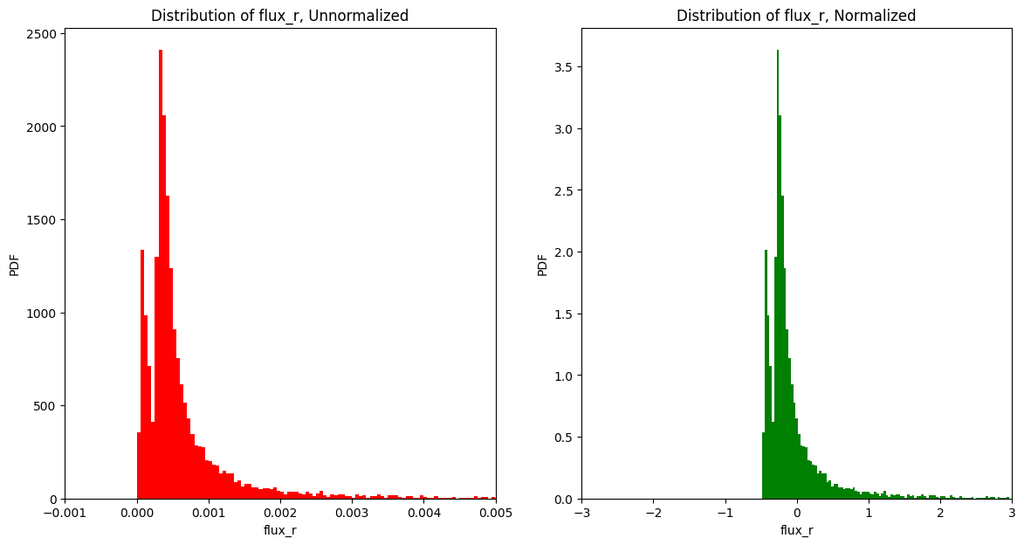

```python
# Choose a parameter from our table
param = 'flux_r'

# Plot the histogram, before and after normalization
fig = plt.figure(figsize = (14, 7))
gs = fig.add_gridspec(1, 2, wspace = 0.2, hspace = 0.0)

# Before normaliztion
ax1 = fig.add_subplot(gs[0, 0])
ax1.title.set_text('Distribution of {0}, Unnormalized'.format(param))
ax1.hist(sp[param], bins = 1000, density = True, color = 'red')
ax1.set_xlabel(param)
ax1.set_xlim([-1e-3, 0.005])
ax1.set_ylabel('PDF')

# After normalization
ax2 = fig.add_subplot(gs[0, 1])
ax2.title.set_text('Distribution of {0}, Normalized'.format(param))
ax2.hist(sp_norm[param], bins = 1000, density = True, color = 'green')
ax2.set_xlabel(param)
ax2.set_xlim([-3, 3])
ax2.set_ylabel('PDF')

plt.show()
```

In the figure above, the left plot shows the flux distribution in one band without normalizing the data. Here the data seems to resemble an exponential distribution with two peaks. This makes sense since if we look at the bivariate distribution of stellar mass and redshift, there are very few galaxies with low stellar mass and high redshift. These galaxies would have the lowest fluxes and would populate the area between the two peaks of the distribution.

The right plot illustrates the same as the left except we normalized each flux measurement according to the normalization defined in the question statement. Here we take each measurement, subtract off its mean and divide by the standard deviation (i.e., we calculate the z-score). The result of this should be to shift the distribution so that the mean value is at $0$ and its standard deviation is $1$. This shouldn't change the shape of the flux distribution, which is what we see comparing our two plots.

# Section 1: Data Compression

#### Question 1

What is a dimensionality reduction technique? Why would you use one?

Dimensionality reduction techniques are algorithms that reduce the dimensions of a dataset while simultaneously losing as little information contained in the data as possible. For example, if our data consisted of $1000$ samples with $10$ data points each, the compression algorithm would attempt to reduce the number of data points per sample while representing the same information.

Dimensionality reduction techniques are mainly used to reduce computation time (i.e., the number of operations required) and/or the amount of information stored.

#### Question 2

There are many different data compression techniques: PCA, UMAP, tSNE, VAE... Pick two of these methods, and explain briefly:

- How do each one of them work?
- What are advantages or disadvantages of each method?
- When would you use one over the other?

Two data compression techniques are PCA and UMAP:

1. PCA: This method attempts to find the principle components of the data. That is, PCA attempts to transform the data into an orientation such that the variance of the projected data is maximized. Ignoring the principle components with less significance (i.e., components with a low fraction of total variance) leads to the dimensionality reduction. The main advantage of PCA is that it is a fast, simple algorithm where transforming the data by the principle components consists of linear operations. The main disadvantage is that if the original data does not lie on or near a lower-dimensional linear subspace, then many principle components will need to be retained in order to keep most of the information in the data.
2. UMAP: This method attempts to embed high dimensional data by searching for a low dimensional projection of the data that has the closest possible equivalent to the original topological structure. It does this by using a cost function that weights preserving global and local structure in the data. The main advantage is UMAP is highly general meaning it can work well on large datasets with many dimensions where the data is non-linear. The main disadvantage is UMAP depends on several hyperparameters that need to be tuned for the dataset. The effectiveness of the embedding is significantly impacted by the choice of hyperparameters.

PCA is most useful if the data lies on or near a linear subspace. In this case, most of the data's information content is retained by the principle components representing the axes of the subspace. On the other hand, UMAP should be used if the data contains non-linear structure.

#### Question 3

Pick one of the dimensionality reduction methods

> Most already have easy-to-use implementations so you don't have to code them from scratch: [PCA](https://scikit-learn.org/stable/modules/generated/sklearn.decomposition.PCA.html), [UMAP](https://umap-learn.readthedocs.io/en/latest/index.html), [tSNR](https://scikit-learn.org/stable/modules/generated/sklearn.manifold.TSNE.html). Training something like a Variational Autoencoder is a more involved task and requires access to a GPU.

Do the following:

1. Reduce your data to 2 dimensions using your chosen algorithm
2. Save your output

   > Remember to keep the IDs with the principal components, so that you can easily see which galaxy those values are for later
3. Plot the two principal variables against each other and describe what you see
   - Are there any obvious patterns in your data?
   - Are there any clusters?!

```python
# Extract the data from our sample table and turn it into a useable form

# Get the columns of the sample table
columns = sp_norm.columns

# Remove the first two columns from our list
col_sel = columns[2:]

# Create a matrix to store the data
DATA = np.zeros((sp_norm.shape[0], len(col_sel)))

# Update the matrix with our data
for i in range(0, len(col_sel)):

    # Update the data in the table with the normalized version
    DATA[:, i] = sp_norm[col_sel[i]].values

# End of for loop
```

```python
# Import Libraries
from sklearn.decomposition import PCA

# Apply PCA to the data
pca = PCA(n_components = 2)
pca.fit(DATA)

# Get the PCA components
PCA_DATA_new = pca.transform(DATA)
```

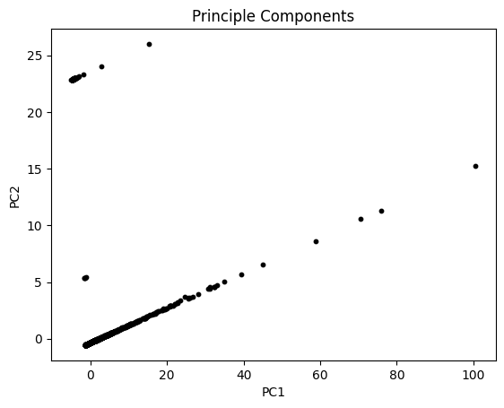

```python
# Create a dataframe to store our PCs
output = pd.DataFrame(data = np.vstack((sp_norm['table_id'].values, sp_norm['id'].values, PCA_DATA_new[:, 0], PCA_DATA_new[:, 1])).T,
                      columns = [sp_norm.columns[0], sp_norm.columns[1], 'PC1', 'PC2'])

# Change the first two columns to be integers
output = output.astype({'table_id': int,
                        'id': int})

## Plot the principle components ##

plt.title('Principle Components')
plt.scatter(output['PC1'].values, output['PC2'].values, color = 'black', s = 10, marker = 'o')
plt.xlabel('PC1')
plt.ylabel('PC2')
plt.show()
```

The figure above shows a plot of the two principle components. The data is clustered into three segments:

1. A linearly varying cluster between (0, 0) to (100, 15).
2. A small circular cluster at (0, 5).
3. A linearly varying cluster between (0, 22) to (20, 26).

Note: The points above represent (PC1, PC2).

The three clusters are largely separated. A majority of the data points lie along the first cluster.

#### Question 4

Now, load in the `sw_output.fits` table and cross-match the two tables to get stellar masses, redshifts, dust opacities, etc.

4. Color the points on your plot above by a physical property and discuss if you see any patterns.

```python
# Load in the output catalogue
with fits.open('../data/sw_output.fits') as f:
    out_cat = Table(f[1].data).to_pandas()
    f.close()

# Merge the input and output catalogues
in_out_cat = pd.merge(df, out_cat, on = 'id')
```

```python
# Select the output catalogue physical properties
params = ['lmass50', 'lsfr50', 'lssfr50', 'ldust50']

# Get the columns of the in_out catalogue
columns = in_out_cat.columns

# Loop over each parameter
p_cols = [0]
for param in params:
    p_cols.append( np.where(columns == '{0}_all'.format(param))[0][0] )
# End of for loop

# Add the redshift column as well
p_cols.append( np.where(columns == 'redshift')[0][0] )

# Merge the PC table with the physical properties
PC_cat = pd.merge(output, in_out_cat[columns[p_cols]], on = 'id')

## Save the PC table with the output catalogue data

# Convert the dataframe to a table
t = Table.from_pandas(PC_cat)

# Save the PCs as a .fits file for later use
fname = '../data/A2 Sample (PCs).fits'
t.write(fname, format = 'fits', overwrite = True)
```

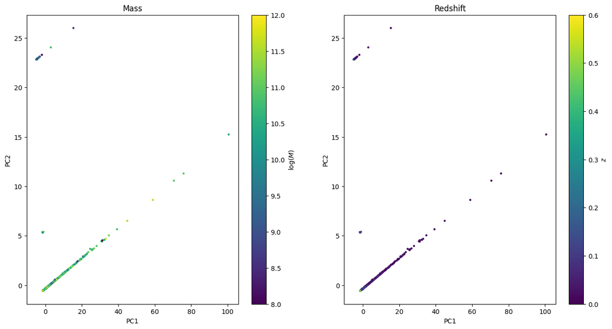

```python
## Plot the PCs coloured by stellar mass and redshift ##

fig = plt.figure(figsize = (16, 8))
gs = fig.add_gridspec(1, 2, wspace = 0.2, hspace = 0.0)

# Add an axes to the plot
ax1 = fig.add_subplot(gs[0, 0])
ax2 = fig.add_subplot(gs[0, 1])

# Add the titles to the plot
ax1.title.set_text('Mass')
ax2.title.set_text('Redshift')

# Add data to the plot
C1 = ax1.scatter(PC_cat['PC1'].values, PC_cat['PC2'].values, c = PC_cat['lmass50_all'],
                 s = 5, marker = 'o', vmin = 8.0, vmax = 12.0)
C2 = ax2.scatter(PC_cat['PC1'].values, PC_cat['PC2'].values, c = PC_cat['redshift'],
                 s = 5, marker = 'o', vmin = 0.0, vmax = 0.6)

# Set the plot axes
ax1.set_xlabel('PC1')
ax1.set_ylabel('PC2')
ax2.set_xlabel('PC1')
ax2.set_ylabel('PC2')

# Add colourbars to each
cbar1 = fig.colorbar(C1, ax = ax1)
cbar1.ax.set_ylabel('$\log(M)$')
cbar2 = fig.colorbar(C2, ax = ax2)
cbar2.ax.set_ylabel('$z$')

plt.show()
```

The figure above shows how the principle components vary with the stellar mass and redshift of each galaxy.

The left plot illustrates the variation with stellar mass. There is no discernible pattern **within** each cluster, however, it appears that the lower two clusters consist of galaxies with stellar masses above $10^{10} M_\odot$, while the upper cluster consists of galaxies with lower stellar masses below this mark.

The right plot depicts the variation with redshift. There is no discernible pattern **between** each cluster, however, it appears that their is some redshift variation between galaxies in the lower and upper clusters (i.e., the linear clusters). The plot shows that in these clusters, the redshift increases as we move towards $\rm{PC1} = 0$, although most of the variation is only seen at the lower end near $\rm{PC1} = 0$.

#### Question 5 [bonus]

If you are feeling brave, you can try several encoding tools - how do your results change? What if you keep more than 2 principal variables? Does changing *hyperparameters* of your algorithm change your results quantitatively / qualitatively?

```python
# Import Libraries
import umap as umap

# Apply UMAP to the data
reducer = umap.UMAP(n_components = 2,
                    n_neighbors = 15,
                    n_jobs = 1,
                    random_state = 30)
reducer.fit(DATA)

# Get the UMAP components
UMAP_DATA_new = reducer.transform(DATA)
```

```python
# Create a dataframe to store our PCs
output = pd.DataFrame(data = np.vstack((sp_norm['table_id'].values, sp_norm['id'].values, UMAP_DATA_new[:, 0], UMAP_DATA_new[:, 1])).T,
                      columns = [sp_norm.columns[0], sp_norm.columns[1], 'PC1', 'PC2'])

# Change the first two columns to be integers
output = output.astype({'table_id': int,
                        'id': int})

# Merge the UMAP table with the physical properties
UMAP_cat = pd.merge(output, in_out_cat[columns[p_cols]], on = 'id')

## Save the UMAP table with the output catalogue data

# Convert the dataframe to a table
t = Table.from_pandas(UMAP_cat)

# Save the PCs as a .fits file for later use
fname = '../data/A2 Sample (UMAPs).fits'
t.write(fname, format = 'fits', overwrite = True)
```

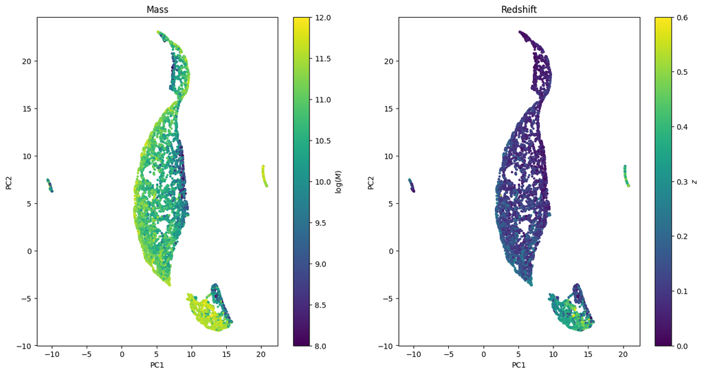

```python
## Plot the PCs coloured by stellar mass and redshift for our UMAP reduction ##

fig = plt.figure(figsize = (16, 8))
gs = fig.add_gridspec(1, 2, wspace = 0.2, hspace = 0.0)

# Add an axes to the plot
ax1 = fig.add_subplot(gs[0, 0])
ax2 = fig.add_subplot(gs[0, 1])

# Add the titles to the plot
ax1.title.set_text('Mass')
ax2.title.set_text('Redshift')

# Add data to the plot
C1 = ax1.scatter(UMAP_cat['PC1'].values, UMAP_cat['PC2'].values, c = UMAP_cat['lmass50_all'],
                 s = 5, marker = 'o', vmin = 8.0, vmax = 12.0)
C2 = ax2.scatter(UMAP_cat['PC1'].values, UMAP_cat['PC2'].values, c = UMAP_cat['redshift'],
                 s = 5, marker = 'o', vmin = 0.0, vmax = 0.6)

# Set the plot axes
ax1.set_xlabel('PC1')
ax1.set_ylabel('PC2')
ax2.set_xlabel('PC1')
ax2.set_ylabel('PC2')

# Add colourbars to each
cbar1 = fig.colorbar(C1, ax = ax1)
cbar1.ax.set_ylabel('$\log(M)$')
cbar2 = fig.colorbar(C2, ax = ax2)
cbar2.ax.set_ylabel('$z$')

plt.show()
```

Compared to using PCA reduction, UMAP finds the data separates into 4 different clusters as opposed to 3. These clusters have more complex shapes compared to the PCA results. The large central cluster is crescent shaped and is mostly composed of low redshift objects with mid-to-high stellar masses. The smaller, quarter circle shaped cluster at the bottom right of the plot is conversely composed of high stellar mass objects at higher redshift.

There are also two sparse, linearly shaped clusters on either side of the largest cluster. These clusters have opposite features. The left one consists of low stellar mass, low redshift objects, while the right one consists of high stellar mass, high redshift objects.

For the UMAP algorithm, the hyperparameter "n_neighbors" controls the degree of local to large scale clustering. For our data, using a low value (i.e., $N = 2$) results in a singular cloud containing all points with very minimal large scale structure. On the other hand, using a high value (i.e., $N = 200$) doesn't change the clustering much for our sample compared to our fiducial case of $N = 15$. The only real difference is the orientation of the clusters in the $2$D reduced space.

# Section 2: Unsupervised ML

In section, you will implement a clustering algorithm to see if there are any *natural* clusters in your data. You can choose any algorithm from the ones shown [on the Scikit-Learn website](https://scikit-learn.org/stable/modules/clustering.html). The best algorithm depends on your data: so refer back to the plots you made in Section 1 to see which algorithm you think will work best.

Load in the subset you chose in the previous section.

```python
# Load in the table with the UMAP principle components
with fits.open('../data/A2 Sample (UMAPs).fits') as f:
    UMAP_cat = Table(f[1].data).to_pandas()
    f.close()

display(UMAP_cat)
```

|  | table_id | id | PC1 | PC2 | lmass50_all | lsfr50_all | lssfr50_all | ldust50_all | redshift |
| --- | --- | --- | --- | --- | --- | --- | --- | --- | --- |
| 0 | 735620 | 2209771 | 5.613947 | 9.674168 | 10.63 | 0.217 | -10.42 | 10.520 | 0.093639 |
| 1 | 345591 | 1036173 | 6.262522 | -2.566058 | 11.15 | -0.158 | -11.27 | 10.590 | 0.184494 |
| 2 | 827643 | 2382326 | 7.272524 | 7.206853 | 10.36 | 0.132 | -10.22 | 10.150 | 0.094066 |
| 3 | 711375 | 2021907 | 5.284271 | 5.742728 | 9.98 | -0.308 | -10.27 | 9.862 | 0.053175 |
| 4 | 21112 | 79066 | 7.820219 | 10.333518 | 10.52 | 0.782 | -9.73 | 10.780 | 0.121823 |
| ... | ... | ... | ... | ... | ... | ... | ... | ... | ... |
| 7995 | 559295 | 1699196 | 14.411766 | -7.497000 | 11.67 | -1.113 | -12.82 | 10.720 | 0.496536 |
| 7996 | 572543 | 1728789 | 5.151955 | 1.859775 | 10.36 | -4.133 | -14.52 | 8.867 | 0.081034 |
| 7997 | 515893 | 1400962 | 2.899580 | 6.692050 | 10.63 | -4.318 | -14.97 | 8.867 | 0.082512 |
| 7998 | 90941 | 313393 | 7.291421 | 14.809869 | 11.35 | -0.578 | -11.87 | 10.460 | 0.122245 |
| 7999 | 734102 | 2206750 | 4.290002 | 4.962508 | 10.73 | -0.368 | -11.07 | 10.150 | 0.109685 |

8000 rows × 9 columns

#### Question 1

Choose a clustering algorithm. Why did you go for this particular one?

The clustering algorithm I chose is **Spectral Clustering**. For our data, it has a few advantages over other methods:

1. The data isn't Gaussian distributed so using Gaussian Mixture Models wouldn't be suitable.
2. The clusters we find visually in Section 1 (for the UMAP reduction) have complex shapes, some of which are non-circular, indicating that K-means is unlikely to split the clusters correctly since this method prefers to create circular clusters.

#### Question 2

Run clustering on your **compressed data**. Think of these questions, if they are relevant to your algorithm - often the *hyperparameters* of your algorithm will need you to answer these.

- How many clusters should you fit to your data?
- Where should the initial guesses for the cluster centers be?
- What should be the typical size for each cluster?

```python
# Import Libraries
from sklearn.cluster import SpectralClustering
from sklearn.metrics import silhouette_score

# Extract the UMAP data
UMAP_DATA_new = np.zeros((len(UMAP_cat['id'].values), 2))
UMAP_DATA_new[:, 0] = UMAP_cat['PC1'].values
UMAP_DATA_new[:, 1] = UMAP_cat['PC2'].values

# Set the hyperparameters for our algorithm
n_jobs = 4
gamma = 0.1

# Set the number of cluster lists
n_list = [2, 3, 4, 5, 6, 7, 8]

# Loop through different numbers of clusters
scores = np.zeros(len(n_list))
for i in range(0, len(n_list)):

    # Apply clustering to our data
    cluster = SpectralClustering(n_clusters = n_list[i],
                                 n_jobs = n_jobs,
                                 gamma = gamma,
                                 random_state = 30)

    labels = cluster.fit_predict(UMAP_DATA_new)

    # Measure and print the silhouette score for clustering
    scores[i] = silhouette_score(UMAP_DATA_new, labels)
    print('Silhouette Score for N = {0} clusters:'.format(n_list[i]), scores[i])

# End of for loop
```

```
Silhouette Score for N = 2 clusters: 0.4649081084568987
Silhouette Score for N = 3 clusters: 0.3512386311367145
Silhouette Score for N = 4 clusters: 0.4443226959120646
Silhouette Score for N = 5 clusters: 0.5177380894090192
Silhouette Score for N = 6 clusters: 0.5258133243708651
Silhouette Score for N = 7 clusters: 0.47998462890732563
Silhouette Score for N = 8 clusters: 0.5073181144254201
```

The results of the clustering algorithm are shown in the print statements above. From the silhouette scores, the algorithm suggests that the number of clusters should be either $5$ or $6$ as opposed to the $4$ we identified in Section 1. The algorithm finds that the large central cluster should be split into either $2$ or $3$ separate clusters. However, based on its structure visually, it is unlikely that this cluster is actually $3$ separate clusters, so we say that it should be split into $2$ instead.

```python
# Set the number of clusters to use for our best model
n_clusters = 5

# Apply clustering to our data
cluster = SpectralClustering(n_clusters = n_clusters,
                             n_jobs = n_jobs,
                             gamma = gamma,
                             random_state = 30)

labels = cluster.fit_predict(UMAP_DATA_new)

# Add 1 to each label so the labels start from 1 for plotting
labels += 1
```

#### Question 3

Plot your compressed data, coloring the points by which cluster they belong it. Optionally, you can also overplot the boundaries of your cluster (see the example [here](https://scikit-learn.org/stable/auto_examples/cluster/plot_kmeans_digits.html#visualize-the-results-on-pca-reduced-data)).

- Do the clusters make sense?
- Do you think you chose the right number of clusters?

You can use this visualization to tune the hyper-parameters of your clustering algorithm to perhaps get a cleaner result.

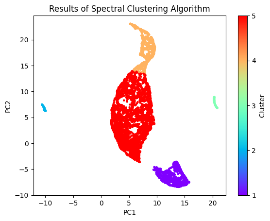

```python
# Plot the compressed data
plt.title('Results of Spectral Clustering Algorithm')
C1 = plt.scatter(UMAP_cat['PC1'].values, UMAP_cat['PC2'].values, c = labels, s = 5, marker = 'o',
                 vmin = min(labels), vmax = max(labels), cmap = 'rainbow')

# Add axis labels
plt.xlabel('PC1')
plt.ylabel('PC2')

# Add a colorbar
cbar = plt.colorbar(C1)
cbar.ax.set_ylabel('Cluster')
cbar.ax.set_yticks(list(range(1, n_clusters + 1)))

plt.show()
```

The results of the clustering algorithm with the best number of clusters is shown in the plot above. Here the algorithm splits the data into $5$ clusters, $3$ of which we identified in Section 1. The fourth cluster, the largest central cluster, is split into $2$ separate clusters, an upper and lower portion. This split seems to make sense visually. In addition, the algorithm successfully classifies each point into their respective clusters.

#### Question 4

Look at the distribution of *physical properties* (mass, redshift, dust...) from the output catalog for each one of your clusters. Are there any statistically significant differences between the clusters in any of these properties?

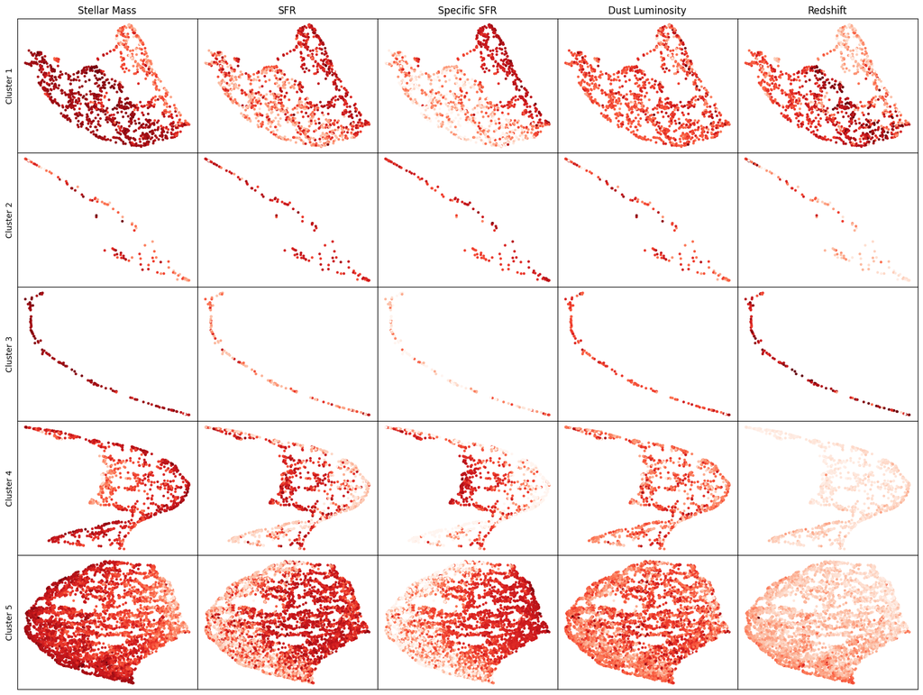

```python
# Add redshift to our parameter list
params = ['lmass50', 'lsfr50', 'lssfr50', 'ldust50', 'redshift']

## Plot the physical properties vs. the clusters ##
fig = plt.figure(figsize = (20, 15))
gs = fig.add_gridspec(n_clusters, len(params), wspace = 0.0, hspace = 0.0)

for i in range(0, n_clusters):
    for j in range(0, len(params)):

        # Add an axis to the plot
        ax = fig.add_subplot(gs[i, j])

        # Determine which parameter we are plotting
        if (j == 0):
            title = 'Stellar Mass'
            pL, pR = 8.0, 12.0
        elif (j == 1):
            title = 'SFR'
            pL, pR = -5.0, 2.0
        elif (j == 2):
            title = 'Specific SFR'
            pL, pR = -14.9, -8.0
        elif (j == 3):
            title = 'Dust Luminosity'
            pL, pR = 8.0, 12.0
        elif (j == 4):
            title = 'Redshift'
            pL, pR = 0.0, 0.5
        # End of if

        # Add the title only if this is the first row
        if (i == 0):
            ax.title.set_text(title)
        # End of if

        # Get the data and the cluster positions
        posns = np.where(labels == int(i + 1))[0]
        if (j == 4):
            params_data = UMAP_cat['redshift'].values
        else:
            params_data = UMAP_cat['{0}_all'.format(params[j])].values
        # End of if

        # Add the data to the plot
        g = ax.scatter(UMAP_cat['PC1'].values[posns], UMAP_cat['PC2'].values[posns], c = params_data[posns], s = 5, marker = 'o',
                       vmin = pL, vmax = pR, cmap = 'Reds')

        # Turn off the tick labels
        ax.set_xticks([])
        ax.set_xticklabels([])
        ax.set_yticks([])
        ax.set_yticklabels([])

        # Add a plot axis for the cluster
        if (j == 0):
            ax.set_ylabel('Cluster {0}'.format(i + 1))
        # End of if

    # End of for loop
# End of for loop
```

Note: In the above plot, the color of each data point represents the value of the physical property. Low values are shown as light red, while high values are shown as dark red. For values that are negative, more negative values are shown as light red, while less negative values are shown as dark red.

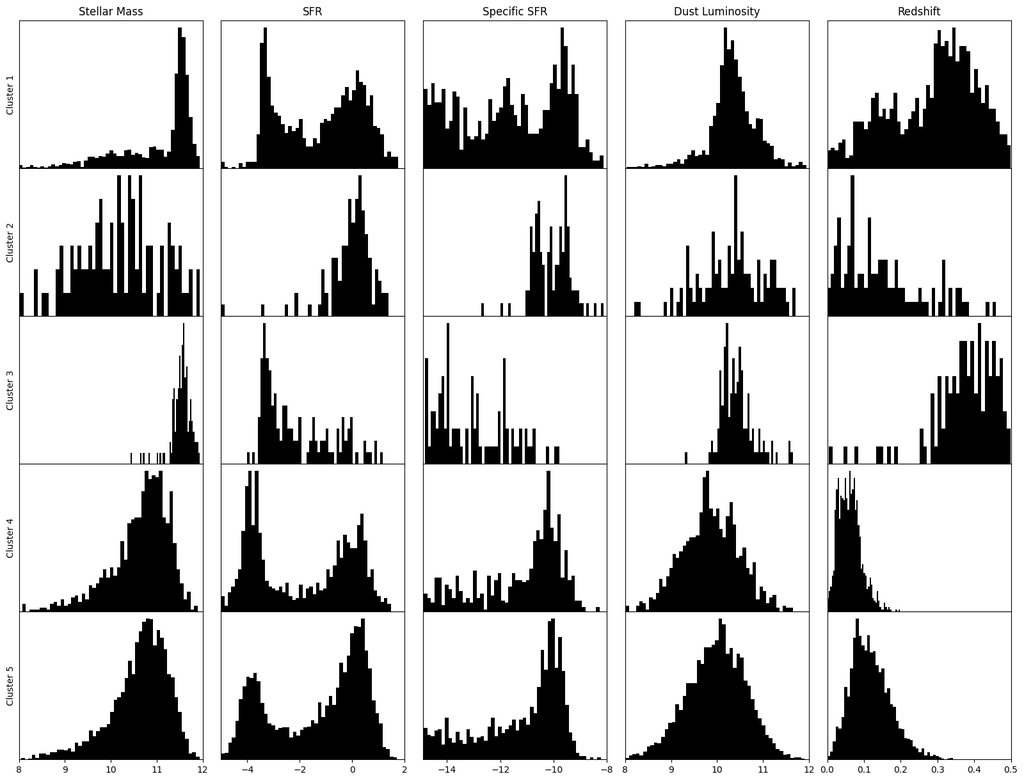

```python
# Add redshift to our parameter list
params = ['lmass50', 'lsfr50', 'lssfr50', 'ldust50', 'redshift']

## Plot the physical properties vs. the clusters ##
fig = plt.figure(figsize = (20, 15))
gs = fig.add_gridspec(n_clusters, len(params), wspace = 0.1, hspace = 0.0)

for i in range(0, n_clusters):
    for j in range(0, len(params)):

        # Add an axis to the plot
        ax = fig.add_subplot(gs[i, j])

        # Determine which parameter we are plotting
        if (j == 0):
            title = 'Stellar Mass'
            pL, pR = 8.0, 12.0
        elif (j == 1):
            title = 'SFR'
            pL, pR = -5.0, 2.0
        elif (j == 2):
            title = 'Specific SFR'
            pL, pR = -14.9, -8.0
        elif (j == 3):
            title = 'Dust Luminosity'
            pL, pR = 8.0, 12.0
        elif (j == 4):
            title = 'Redshift'
            pL, pR = 0.0, 0.5
        # End of if

        # Add the title only if this is the first row
        if (i == 0):
            ax.title.set_text(title)
        # End of if

        # Get the data and the cluster positions
        posns = np.where(labels == int(i + 1))[0]
        if (j == 4):
            params_data = UMAP_cat['redshift'].values[posns]
        else:
            params_data = UMAP_cat['{0}_all'.format(params[j])].values[posns]
        # End of if

        # Add data to the plot
        ax.hist(params_data[(pL <= params_data) & (params_data <= pR)], bins = 50, density = True, color = 'black')
        ax.set_xlim([pL, pR])

        # Turn off specific x-tick labels
        if (i != (n_clusters - 1)):
            ax.set_xticks([])
            ax.set_xticklabels([])
        # End of if

        # Turn off the y-tick labels
        ax.set_yticks([])
        ax.set_yticklabels([])

        # Add a plot axis for the cluster
        if (j == 0):
            ax.set_ylabel('Cluster {0}'.format(i + 1))
        # End of if

    # End of for loop
# End of for loop
```

The figure above depicts how the distribution of each physical property for our galaxy sample varies between our $5$ clusters. Each row shows a different cluster and each column shows a different physical property.

We will discuss each physical property below:

It is clear from the plots above that redshift has the most statistically significant differences between the clusters.

#### Question 5

Repeat **questions 2 and 4** but using your full dataset instead of the compressed one.

- Do you see any differences in your results?
- Did you need to choose different hyperparameters?

```python
# Set the hyperparameters for our algorithm
n_jobs = 4
gamma = 0.01

# Set the number of cluster lists
n_list = [2, 3, 4, 5, 6, 7, 8]

# Loop through different numbers of clusters
scores = np.zeros(len(n_list))
for i in range(0, len(n_list)):

    # Apply clustering to our data
    cluster = SpectralClustering(n_clusters = n_list[i],
                                 n_jobs = n_jobs,
                                 gamma = gamma,
                                 random_state = 30)

    labels = cluster.fit_predict(DATA)

    # Measure and print the silhouette score for clustering
    scores[i] = silhouette_score(DATA, labels)
    print('Silhouette Score for N = {0} clusters:'.format(n_list[i]), scores[i])

# End of for loop
```

```
Silhouette Score for N = 2 clusters: 0.9712695503920694
Silhouette Score for N = 3 clusters: 0.9598742021030573
Silhouette Score for N = 4 clusters: 0.9322705987737134
Silhouette Score for N = 5 clusters: 0.9462673864411074
Silhouette Score for N = 6 clusters: 0.9293757247589803
Silhouette Score for N = 7 clusters: 0.927489923083147
Silhouette Score for N = 8 clusters: 0.9168013445855793
```

The silhouette scores for different numbers of clusters is printed above. Here, our dataset is the full uncompressed one. Note that we change one of the hyperparameters, "gamma", compared to previous parts. We tried a range of gamma from $0.001 - 1.0$, but this didn't change the results.

The silhouette scores above indicate that the clustering algorithm was unable to find clusters in the uncompressed data. The scores generally decrease with increasing numbers of clusters. At times when the silhouette score increases with increasing cluster number, each cluster typically has very few data points. For example, when $N = 5$, there is one main cluster with most of the data points, and the remaining four clusters either have one or two data points.

For our histogram comparison, we will choose $N = 2$.

```python
# Set the number of clusters to use for our best model
n_clusters = 2

# Apply clustering to our data
cluster = SpectralClustering(n_clusters = n_clusters,
                             n_jobs = n_jobs,
                             gamma = gamma,
                             random_state = 30)

labels = cluster.fit_predict(DATA)

# Add 1 to each label so the labels start from 1 for plotting
labels += 1
```

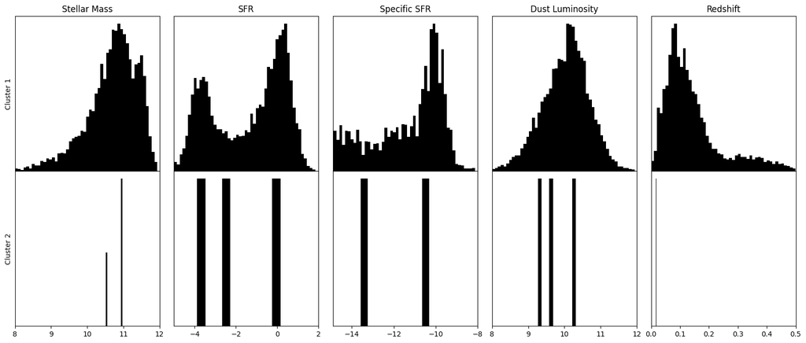

```python
# Add redshift to our parameter list
params = ['lmass50', 'lsfr50', 'lssfr50', 'ldust50', 'redshift']

## Plot the physical properties vs. the clusters ##
fig = plt.figure(figsize = (20, 8))
gs = fig.add_gridspec(n_clusters, len(params), wspace = 0.1, hspace = 0.0)

for i in range(0, n_clusters):
    for j in range(0, len(params)):

        # Add an axis to the plot
        ax = fig.add_subplot(gs[i, j])

        # Determine which parameter we are plotting
        if (j == 0):
            title = 'Stellar Mass'
            pL, pR = 8.0, 12.0
        elif (j == 1):
            title = 'SFR'
            pL, pR = -5.0, 2.0
        elif (j == 2):
            title = 'Specific SFR'
            pL, pR = -14.9, -8.0
        elif (j == 3):
            title = 'Dust Luminosity'
            pL, pR = 8.0, 12.0
        elif (j == 4):
            title = 'Redshift'
            pL, pR = 0.0, 0.5
        # End of if

        # Add the title only if this is the first row
        if (i == 0):
            ax.title.set_text(title)
        # End of if

        # Get the data and the cluster positions
        posns = np.where(labels == int(i + 1))[0]
        if (j == 4):
            params_data = UMAP_cat['redshift'].values[posns]
        else:
            params_data = UMAP_cat['{0}_all'.format(params[j])].values[posns]
        # End of if

        # Choose the number of bins
        if (i == 0):
            bins = 50
        elif (i == 1):
            bins = 10
        # End of if

        # Add data to the plot
        ax.hist(params_data[(pL <= params_data) & (params_data <= pR)], bins = bins, density = True, color = 'black')
        ax.set_xlim([pL, pR])

        # Turn off specific x-tick labels
        if (i != (n_clusters - 1)):
            ax.set_xticks([])
            ax.set_xticklabels([])
        # End of if

        # Turn off the y-tick labels
        ax.set_yticks([])
        ax.set_yticklabels([])

        # Add a plot axis for the cluster
        if (j == 0):
            ax.set_ylabel('Cluster {0}'.format(i + 1))
        # End of if

    # End of for loop
# End of for loop
```

The results here demonstrate that data compression was necessary in order to identify any clustering. Using spectral clustering on the uncompressed dataset was unable to separate the data into meaningful clusters.

# Section 3: Supervised ML

Finally, we can use *supervised ML* to train an algorithm that predicts our relevant physical parameters (mass, redshift, etc.) from the input data directly. This is a regression task, since we want to predict a continuous variable.

You should aim to **predict mass and redshift** of galaxies, but you can also try to predict more properties available in the output catalog.

#### Question 1

Choose a regression tool (e.g., a linear model, SVM, neural network, gaussian process, decision tree... see [more examples here](https://scikit-learn.org/stable/supervised_learning.html#supervised-learning)).

Why did you choose this particular one?

- You can either train N different models for mass, redshift, etc.; or you can train a single model that predicts N parameters simultaneously.
- Think: how many variables do you want to predict, what does your data look like, what relationship do you see by eye between your input and output data...

The regression tool I chose is **Decision Trees**. For our data, it has a few advantages over other methods:

1. SVMs generally work best as classifiers and here we are looking at a regression problem.
2. Linear, Lasso, and Ridge regression fit models that are linear in the model parameters, which may not be true in this case.
3. Decision trees can capture non-linear relationships and they are more robust, working for most types of input data.

#### Question 2

Split your data into two sub-samples: one for training and one for validation

Use the tool you chose to predict the physical parameters from the input *training* data.

- Optimize the parameters of the model
- What is the correlation between predicted mass/redshift/other parameters, or the errors in the predictions?

```python
# Import Libaries
from sklearn.tree import DecisionTreeRegressor, plot_tree
from sklearn.model_selection import train_test_split, RandomizedSearchCV
from sklearn.metrics import mean_squared_error

# Get the input X-data
columns = sp_norm.columns[2:]
X_DATA = np.zeros((sp_norm.shape[0], len(columns)))
for i in range(0, len(columns)):
    X_DATA[:, i] = sp_norm[columns[i]].values

# Get the output Y-data
columns = UMAP_cat.columns[[4, 8]]
Y_DATA = np.zeros((UMAP_cat.shape[0], len(columns)))
for i in range(0, len(columns)):
    Y_DATA[:, i] = UMAP_cat[columns[i]].values

# Remove samples with unrealistic stellar masses
filter = (8.0 <= Y_DATA[:, 0]) & (Y_DATA[:, 0] <= 12.0)
Y_DATA = Y_DATA[filter, :]
X_DATA = X_DATA[filter, :]

# Remove samples with unrealistic redshifts
filter = (0.0 <= Y_DATA[:, 1]) & (Y_DATA[:, 1] <= 0.8)
Y_DATA = Y_DATA[filter, :]
X_DATA = X_DATA[filter, :]

# Set the random state
state = 30

# Split data into training and validation sets
X_train, X_test, Y_train, Y_test = train_test_split(X_DATA, Y_DATA, test_size = 0.20, random_state = state)

# Setup the base decision tree
DT = DecisionTreeRegressor(random_state = state)

# Setup the randomized search parameters
params = {'max_depth': stats.randint(2, 128),
          'min_samples_leaf': stats.randint(1, int(0.02*X_train.shape[0]))}
```

```python
## Stellar Mass ##

# Search for the optimal parameters
search_Mass = RandomizedSearchCV(estimator = DT, param_distributions = params, n_iter = 1000, n_jobs = 4)
search_Mass.fit(X_train, Y_train[:, 0])

# Put the results into a dataframe
res_Mass = pd.DataFrame(search_Mass.cv_results_)

# Extract the models with the highest rank (by rank_test_score)
res_Mbest = res_Mass.query('rank_test_score == 1')

# Get the model hyperparameters for stellar mass
# Note: min_samples_leaf should be the same for all rank = 1 models
#       We want to choose the minimum max depth since higher values do
#       not improve the tree
min_samples_leaf_Mass = min(res_Mbest['param_min_samples_leaf'].values.T)
max_depth_Mass = min(res_Mbest['param_max_depth'].values.T)

# Train the best-fit model for stellar mass
DT_Mass = DecisionTreeRegressor(max_depth = max_depth_Mass,
                                min_samples_leaf = min_samples_leaf_Mass,
                                random_state = state)
DT_Mass.fit(X_train, Y_train[:, 0])
```

```
DecisionTreeRegressor(max_depth=17, min_samples_leaf=15, random_state=30)
```

```python
## Redshift ##

# Search for the optimal parameters
search_Redshift = RandomizedSearchCV(estimator = DT, param_distributions = params, n_iter = 1000, n_jobs = 4)
search_Redshift.fit(X_train, Y_train[:, 1])

# Put the results into a dataframe
res_Redshift = pd.DataFrame(search_Redshift.cv_results_)

# Extract the models with the highest rank (by rank_test_score)
res_Rbest = res_Redshift.query('rank_test_score == 1')

# Get the model hyperparameters for redshift
# Note: min_samples_leaf should be the same for all rank = 1 models
#       We want to choose the minimum max depth since higher values do
#       not improve the tree
min_samples_leaf_Red = min(res_Rbest['param_min_samples_leaf'].values.T)
max_depth_Red = min(res_Rbest['param_max_depth'].values.T)

# Train the best-fit model for redshift
DT_Redshift = DecisionTreeRegressor(max_depth = max_depth_Red,
                                    min_samples_leaf = min_samples_leaf_Red,
                                    random_state = state)
DT_Redshift.fit(X_train, Y_train[:, 1])
```

```
DecisionTreeRegressor(max_depth=28, min_samples_leaf=19, random_state=30)
```

```python
# Predict stellar masses and redshifts for our TRAINING SET
print('Results for the training set: \n')
Mass_train_pred = DT_Mass.predict(X_train)
Red_train_pred = DT_Redshift.predict(X_train)

# Print stellar mass accuracy and mean square error
print('Stellar Mass:')
print('Mean squared error:', mean_squared_error(Y_train[:, 0], Mass_train_pred))
print('Accuracy Score:', DT_Mass.score(X_train, Y_train[:, 0]))
print('\n')

# Print redshift accuracy and mean square error
print('Redshift:')
print('Mean squared error:', mean_squared_error(Y_train[:, 1], Red_train_pred))
print('Accuracy Score:', DT_Redshift.score(X_train, Y_train[:, 1]))
print('\n')

# Compute the correlation between predicted mass and redshift for our TRAINING SET
print('Stellar Mass/Redshift Correlation:')
print(np.corrcoef(Mass_train_pred, Red_train_pred))
```

```
Results for the training set:

Stellar Mass:
Mean squared error: 0.05757743979125774
Accuracy Score: 0.8808922977920302


Redshift:
Mean squared error: 0.0009349923550553262
Accuracy Score: 0.9115680679483026


Stellar Mass/Redshift Correlation:
[[1.         0.62529521]
 [0.62529521 1.        ]]
```

Note: In the results above, the correlation between predicted stellar mass and redshift is given by either off-diagonal element in the matrix.

#### Question 3

Use your model to predict the physical parameters of your validation sample

- What is the accuracy? Is the model performing as well as you expected?

```python
# Predict stellar masses and redshifts for our TEST SET
print('Results for the test set: \n')
Mass_test_pred = DT_Mass.predict(X_test)
Red_test_pred = DT_Redshift.predict(X_test)

# Print stellar mass accuracy and mean square error
print('Stellar Mass:')
print('Mean squared error:', mean_squared_error(Y_test[:, 0], Mass_test_pred))
print('Accuracy Score:', DT_Mass.score(X_test, Y_test[:, 0]))
print('\n')

# Print redshift accuracy and mean square error
print('Redshift:')
print('Mean squared error:', mean_squared_error(Y_test[:, 1], Red_test_pred))
print('Accuracy Score:', DT_Redshift.score(X_test, Y_test[:, 1]))
```

```
Results for the test set:

Stellar Mass:
Mean squared error: 0.10127555766408229
Accuracy Score: 0.7869723896972406


Redshift:
Mean squared error: 0.0014635555172745108
Accuracy Score: 0.8638622181088982
```

The results above describe the accuracy of our model in predicting physical properties for the validation set. Overall, the model performs very well in an average sense. For both stellar mass and redshift, the mean squared error for our test set is small relative to the scale of the physical properties we are trying to predict. The coefficient of determination for our prediction ("score") is also high compared to the best possible score of $1$. Futhermore, the accuracy of our test set is similar to that of our training sample, which can indicate that we are not overfitting our model to our training set.

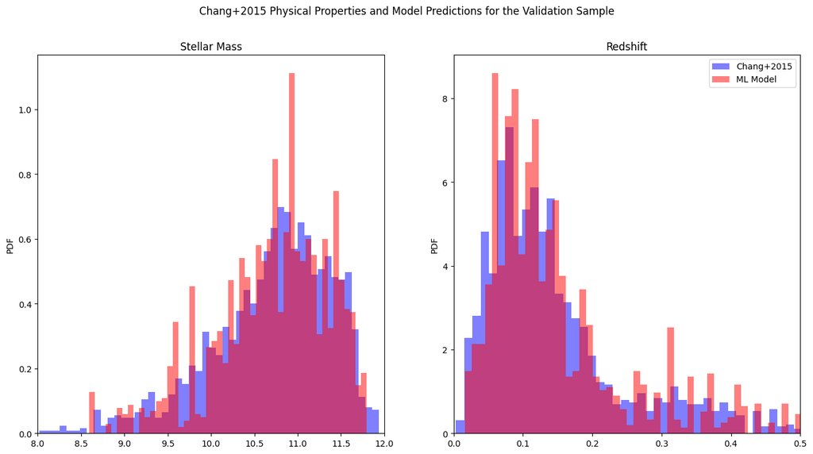

```python
# Plot distributions of real and model predictions for the test set
fig = plt.figure(figsize = (16, 8))
gs = fig.add_gridspec(1, 2, wspace = 0.2, hspace = 0.0)

# Add axes to the plot
ax1 = fig.add_subplot(gs[0, 0])
ax2 = fig.add_subplot(gs[0, 1])

# Add titles to the plot
fig.suptitle('Chang+2015 Physical Properties and Model Predictions for the Validation Sample')
ax1.title.set_text('Stellar Mass')
ax2.title.set_text('Redshift')

# Add the data to the plots
ax1.hist(Y_test[:, 0], bins = 50, density = True, color = 'blue', alpha = 0.5, zorder = 1)
ax1.hist(Mass_test_pred, bins = 50, density = True, color = 'red', alpha = 0.5, zorder = 2)
ax2.hist(Y_test[:, 1], bins = 50, density = True, color = 'blue', alpha = 0.5, zorder = 1, label = 'Chang+2015')
ax2.hist(Red_test_pred, bins = 50, density = True, color = 'red', alpha = 0.5, zorder = 2, label = 'ML Model')

# Add labels to the axes
ax1.set_xlim([8.0, 12.0])
ax1.set_ylabel('PDF')
ax2.set_xlim([0.0, 0.5])
ax2.set_ylabel('PDF')

# Add a legend
ax2.legend()

plt.show()
```

The figure above shows the distribution of physical properties from Chang+2015 for our validation sample compared to the predictions from our ML model. The model predictions are shown in red, while the physical properties from the output table are shown in blue.

We see that our model predictions have pretty good overlap with the properties from Chang+2015. Our model for stellar mass is worse than that for redshift, although not be a large margin. For both models, we find that the predictions favour certain bins more than others leading to sharp peaks in the PDF. This is a result of the predictions from decision trees being discrete in physical property being predicted. Thus, certain values of the physical property, stellar mass for example, would never be predicted exactly.

#### Question 4

Load in `test_sample.csv` and use your model to predict physical parameters.

- What is the accuracy? Is the model performing as well as you expected?
- Why do you think the performance is what it is?

```python
# Read in test_sample.csv
id_table = pd.read_csv('../data/test_sample.csv')

# Get the sample from the input catalogue and
# filter the data table for fluxes/errors
columns = df.columns
pick = [0, 26, 27, 28, 29, 30, 31, 32, 33, 34, 35, 36, 37, 38, 39, 40, 41, 42, 43]
sample_new = pd.merge(df[columns[pick]], id_table, on = 'id')

# Normalize the data in the same way our model was trained
columns = sample_new.columns[1:]
for i in range(0, len(columns)):
    sample_new[columns[i]] = (sample_new[columns[i]].values - S_mean[i]) / S_std[i]

# Merge this sample with the galaxies in the output table
columns = in_out_cat.columns
sample_all = pd.merge(sample_new, in_out_cat[columns[p_cols]], on = 'id')

display(sample_all)
```

|  | id | flux_u | flux_u_e | flux_g | flux_g_e | flux_r | flux_r_e | flux_i | flux_i_e | flux_z | ... | flux_w2_e | flux_w3 | flux_w3_e | flux_w4 | flux_w4_e | lmass50_all | lsfr50_all | lssfr50_all | ldust50_all | redshift |
| --- | --- | --- | --- | --- | --- | --- | --- | --- | --- | --- | --- | --- | --- | --- | --- | --- | --- | --- | --- | --- | --- |
| 0 | 2399 | 0.124037 | 0.226275 | -0.021361 | -0.006542 | -0.188062 | -0.184097 | -0.255927 | -0.253124 | -0.291283 | ... | -0.120834 | -0.122487 | -0.121454 | -0.122397 | -0.120943 | 9.57 | -0.458 | -10.02 | 9.542 | 0.074310 |
| 1 | 3703 | -0.441429 | -0.300578 | -0.422178 | -0.335073 | -0.435526 | -0.392708 | -0.439501 | -0.421512 | -0.442230 | ... | -0.120835 | -0.121977 | -0.121417 | -0.122397 | -0.120896 | 10.40 | 0.262 | -10.12 | 10.520 | 0.183184 |
| 2 | 4499 | -0.479431 | -0.500665 | -0.461424 | -0.406824 | -0.481448 | -0.455593 | -0.468795 | -0.461377 | -0.442939 | ... | -0.120655 | -0.120285 | -0.121226 | -0.122396 | -0.120508 | 10.88 | -4.123 | -14.97 | 10.570 | 0.071107 |
| 3 | 49565 | -0.113437 | -0.180874 | -0.225191 | -0.210458 | -0.304308 | -0.294569 | -0.293819 | -0.290194 | -0.297779 | ... | -0.120767 | -0.120386 | -0.121290 | -0.120383 | -0.121230 | 10.63 | 1.107 | -9.48 | 11.080 | 0.147038 |
| 4 | 60760 | 16.398787 | 13.712832 | 18.217655 | 15.959277 | 18.582722 | 17.654299 | 18.723732 | 18.315094 | 18.783113 | ... | -0.107532 | 3.178033 | 0.159984 | 5.096694 | 0.403180 | 10.43 | 0.577 | -9.88 | 11.580 | 0.007085 |
| ... | ... | ... | ... | ... | ... | ... | ... | ... | ... | ... | ... | ... | ... | ... | ... | ... | ... | ... | ... | ... | ... |
| 249 | 2478918 | 0.033965 | -0.075918 | -0.152194 | -0.146459 | -0.267757 | -0.259834 | -0.300512 | -0.296742 | -0.335068 | ... | -0.120831 | -0.122286 | -0.121454 | -0.122397 | -0.121043 | 9.96 | 0.497 | -9.48 | 10.300 | 0.125529 |
| 250 | 2481618 | 0.050403 | -0.059943 | -0.140788 | -0.136458 | -0.268160 | -0.260216 | -0.311765 | -0.307752 | -0.349666 | ... | -0.120838 | -0.122572 | -0.121454 | -0.122397 | -0.120961 | 9.80 | 0.387 | -9.43 | 10.060 | 0.119234 |
| 251 | 2493521 | 0.360674 | 0.363345 | -0.003314 | -0.015929 | -0.224600 | -0.218821 | -0.290984 | -0.287420 | -0.344447 | ... | -0.120840 | -0.122824 | -0.121339 | -0.122397 | -0.120921 | 8.56 | -0.578 | -9.12 | 8.792 | 0.032049 |
| 252 | 2498386 | -0.383854 | -0.305086 | -0.465400 | -0.396739 | -0.412503 | -0.397390 | -0.410306 | -0.404155 | -0.413900 | ... | 8.279894 | 8.243467 | 8.243604 | 8.279731 | 8.279892 | 9.96 | -1.903 | -11.82 | 9.602 | 0.077587 |
| 253 | 2506669 | 0.288964 | 0.147530 | -0.035707 | -0.044329 | -0.226585 | -0.220707 | -0.297147 | -0.293449 | -0.346553 | ... | -0.120840 | -0.122359 | -0.121433 | -0.122396 | -0.120268 | 9.75 | 0.692 | -9.07 | 10.390 | 0.127364 |

254 rows × 24 columns

```python
# Get the input X-data
columns = sample_all.columns[1:19]
X_SAMPLE = np.zeros((sample_all.shape[0], len(columns)))
for i in range(0, len(columns)):
    X_SAMPLE[:, i] = sample_all[columns[i]].values

# Get the output Y-data
columns = sample_all.columns[[19, 23]]
Y_SAMPLE = np.zeros((sample_all.shape[0], len(columns)))
for i in range(0, len(columns)):
    Y_SAMPLE[:, i] = sample_all[columns[i]].values

# Remove samples with unrealistic stellar masses
filter = (8.0 <= Y_SAMPLE[:, 0]) & (Y_SAMPLE[:, 0] <= 12.0)
Y_SAMPLE = Y_SAMPLE[filter, :]
X_SAMPLE = X_SAMPLE[filter, :]

# Remove samples with unrealistic redshifts
filter = (0.0 <= Y_SAMPLE[:, 1]) & (Y_SAMPLE[:, 1] <= 0.8)
Y_SAMPLE = Y_SAMPLE[filter, :]
X_SAMPLE = X_SAMPLE[filter, :]
```

```python
# Predict stellar masses and redshifts for our TEST SAMPLE
print('Results for test_sample.csv: \n')
Mass_sample_pred = DT_Mass.predict(X_SAMPLE)
Red_sample_pred = DT_Redshift.predict(X_SAMPLE)

# Print stellar mass accuracy and mean square error
print('Stellar Mass:')
print('Mean squared error:', mean_squared_error(Y_SAMPLE[:, 0], Mass_sample_pred))
print('Accuracy Score:', DT_Mass.score(X_SAMPLE, Y_SAMPLE[:, 0]))
print('\n')

# Print redshift accuracy and mean square error
print('Redshift:')
print('Mean squared error:', mean_squared_error(Y_SAMPLE[:, 1], Red_sample_pred))
print('Accuracy Score:', DT_Redshift.score(X_SAMPLE, Y_SAMPLE[:, 1]))
```

```
Results for test_sample.csv:

Stellar Mass:
Mean squared error: 0.39678040076635446
Accuracy Score: 0.12081888639310123


Redshift:
Mean squared error: 0.0044772215372923104
Accuracy Score: -0.6302821753129109
```

The results above describe the accuracy of our model in predicting physical properties for test_sample.csv. Overall, the model performs very poorly for both stellar mass and redshift compared to our training and validation sets. Naively, I thought that the model performance would be much better than this and would be similar to the validation sample we had in Question 3. The primary reason for differences in performance will be shown below.

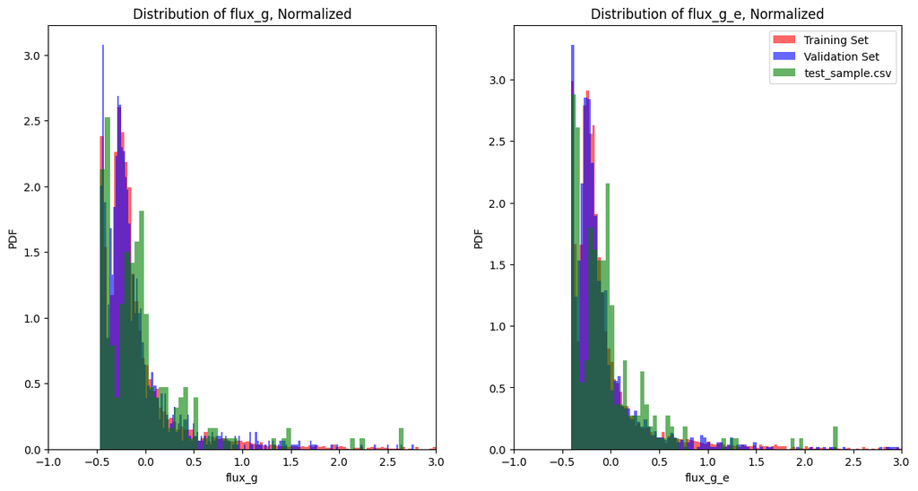

```python
# Choose a parameter from our table
param = 'flux_g'

# Find where in our data the column is
col_idx = np.where(sample_all.columns == param)[0][0] - 1

# Plot the histogram of fluxes for each set
fig = plt.figure(figsize = (14, 7))
gs = fig.add_gridspec(1, 2, wspace = 0.2, hspace = 0.0)

# Flux
ax1 = fig.add_subplot(gs[0, 0])
ax1.title.set_text('Distribution of {0}, Normalized'.format(param))
ax1.hist(X_train[:, col_idx], bins = 1000, density = True, color = 'red', alpha = 0.6)
ax1.hist(X_test[:, col_idx], bins = 1000, density = True, color = 'blue', alpha = 0.6)
ax1.hist(X_SAMPLE[:, col_idx], bins = 1000, density = True, color = 'green', alpha = 0.6)
ax1.set_xlabel(param)
ax1.set_xlim([-1, 3])
ax1.set_ylabel('PDF')

# Flux error
ax2 = fig.add_subplot(gs[0, 1])
ax2.title.set_text('Distribution of {0}, Normalized'.format(param + '_e'))
ax2.hist(X_train[:, col_idx + 1], bins = 1000, density = True, color = 'red', alpha = 0.6, label = 'Training Set')
ax2.hist(X_test[:, col_idx + 1], bins = 1000, density = True, color = 'blue', alpha = 0.6, label = 'Validation Set')
ax2.hist(X_SAMPLE[:, col_idx + 1], bins = 1000, density = True, color = 'green', alpha = 0.6, label = 'test_sample.csv')
ax2.set_xlabel(param + '_e')
ax2.set_xlim([-1, 3])
ax2.set_ylabel('PDF')
ax2.legend()

plt.show()
```

The figure above shows the distributions for the training, validation, and test_sample.csv sets for one flux band and its error, after normalization. For test_sample.csv, the distribution was normalized using the same mean and standard deviation as the training and validation samples. Here we see that the training and validation samples have much greater overlap in their distributions compared to test_sample.csv. This is not only true for this particular band but all $9$ bands as well, compounding this effect.

This likely explains why the model performance is poor for test_sample.csv compared to the validation set. Decision trees are not good at extrapolation. The input data for the validation set looks much more similar to the training data compared to test_sample.csv.

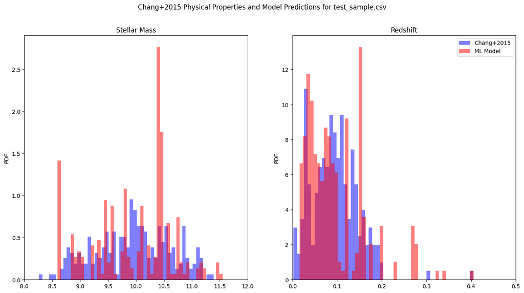

```python
# Plot distributions of real and model predictions for test_sample.csv
fig = plt.figure(figsize = (16, 8))
gs = fig.add_gridspec(1, 2, wspace = 0.2, hspace = 0.0)

# Add axes to the plot
ax1 = fig.add_subplot(gs[0, 0])
ax2 = fig.add_subplot(gs[0, 1])

# Add titles to the plot
fig.suptitle('Chang+2015 Physical Properties and Model Predictions for test_sample.csv')
ax1.title.set_text('Stellar Mass')
ax2.title.set_text('Redshift')

# Add the data to the plots
ax1.hist(Y_SAMPLE[:, 0], bins = 50, density = True, color = 'blue', alpha = 0.5, zorder = 1)
ax1.hist(Mass_sample_pred, bins = 50, density = True, color = 'red', alpha = 0.5, zorder = 2)
ax2.hist(Y_SAMPLE[:, 1], bins = 50, density = True, color = 'blue', alpha = 0.5, zorder = 1, label = 'Chang+2015')
ax2.hist(Red_sample_pred, bins = 50, density = True, color = 'red', alpha = 0.5, zorder = 2, label = 'ML Model')

# Add labels to the axes and a legend
ax1.set_xlim([8.0, 12.0])
ax1.set_ylabel('PDF')
ax2.set_xlim([0.0, 0.5])
ax2.set_ylabel('PDF')
ax2.legend()

plt.show()
```

#### Question 5 [bonus]

Repeat steps 1-4 for the *compressed* dataset. Do you see any differences in performance?

```python
# Get the input X-data
columns = UMAP_cat.columns[[2, 3]]
X_DATA = np.zeros((UMAP_cat.shape[0], len(columns)))
for i in range(0, len(columns)):
    X_DATA[:, i] = UMAP_cat[columns[i]].values

# Get the output Y-data
columns = UMAP_cat.columns[[4, 8]]
Y_DATA = np.zeros((UMAP_cat.shape[0], len(columns)))
for i in range(0, len(columns)):
    Y_DATA[:, i] = UMAP_cat[columns[i]].values

# Remove samples with unrealistic stellar masses
filter = (8.0 <= Y_DATA[:, 0]) & (Y_DATA[:, 0] <= 12.0)
Y_DATA = Y_DATA[filter, :]
X_DATA = X_DATA[filter, :]

# Remove samples with unrealistic redshifts
filter = (0.0 <= Y_DATA[:, 1]) & (Y_DATA[:, 1] <= 0.8)
Y_DATA = Y_DATA[filter, :]
X_DATA = X_DATA[filter, :]

# Split data into training and validation sets
# Note: since our random state is the same as previously, the training and test
#       data will be split into the same galaxies as with the uncompressed data
X_train, X_test, Y_train, Y_test = train_test_split(X_DATA, Y_DATA, test_size = 0.20, random_state = state)

# Setup the base decision tree
DT = DecisionTreeRegressor(random_state = state)

# Setup the randomized search parameters
params = {'max_depth': stats.randint(2, 128),
          'min_samples_leaf': stats.randint(1, int(0.02*X_train.shape[0]))}
```

```python
## Stellar Mass ##

# Search for the optimal parameters
search_Mass = RandomizedSearchCV(estimator = DT, param_distributions = params, n_iter = 1000, n_jobs = 4)
search_Mass.fit(X_train, Y_train[:, 0])

# Put the results into a dataframe
res_Mass = pd.DataFrame(search_Mass.cv_results_)

# Extract the models with the highest rank (by rank_test_score)
res_Mbest = res_Mass.query('rank_test_score == 1')

# Get the model hyperparameters for stellar mass
# Note: min_samples_leaf should be the same for all rank = 1 models
#       We want to choose the minimum max depth since higher values do
#       not improve the tree
min_samples_leaf_Mass = min(res_Mbest['param_min_samples_leaf'].values.T)
max_depth_Mass = min(res_Mbest['param_max_depth'].values.T)

# Train the best-fit model for stellar mass
DT_Mass2 = DecisionTreeRegressor(max_depth = max_depth_Mass,
                                 min_samples_leaf = min_samples_leaf_Mass,
                                 random_state = state)
DT_Mass2.fit(X_train, Y_train[:, 0])
```

```
DecisionTreeRegressor(max_depth=15, min_samples_leaf=8, random_state=30)
```

```python
## Redshift ##
search_Redshift = RandomizedSearchCV(estimator = DT, param_distributions = params, n_iter = 1000, n_jobs = 4)
search_Redshift.fit(X_train, Y_train[:, 1])

# Put the results into a dataframe
res_Redshift = pd.DataFrame(search_Redshift.cv_results_)

# Extract the models with the highest rank (by rank_test_score)
res_Rbest = res_Redshift.query('rank_test_score == 1')

# Get the model hyperparameters for redshift
# Note: min_samples_leaf should be the same for all rank = 1 models
#       We want to choose the minimum max depth since higher values do
#       not improve the tree
min_samples_leaf_Red = min(res_Rbest['param_min_samples_leaf'].values.T)
max_depth_Red = min(res_Rbest['param_max_depth'].values.T)

# Train the best-fit model for redshift
DT_Redshift2 = DecisionTreeRegressor(max_depth = max_depth_Red,
                                     min_samples_leaf = min_samples_leaf_Red,
                                     random_state = state)
DT_Redshift2.fit(X_train, Y_train[:, 1])
```

```
DecisionTreeRegressor(max_depth=22, min_samples_leaf=22, random_state=30)
```

```python
# Predict stellar masses and redshifts for our TRAINING SET
print('Results for the training set for the UMAP reduced data: \n')
Mass_train_pred = DT_Mass2.predict(X_train)
Red_train_pred = DT_Redshift2.predict(X_train)

# Print stellar mass accuracy and mean square error
print('Stellar Mass:')
print('Mean squared error:', mean_squared_error(Y_train[:, 0], Mass_train_pred))
print('Accuracy Score:', DT_Mass2.score(X_train, Y_train[:, 0]))
print('\n')

# Print redshift accuracy and mean square error
print('Redshift:')
print('Mean squared error:', mean_squared_error(Y_train[:, 1], Red_train_pred))
print('Accuracy Score:', DT_Redshift2.score(X_train, Y_train[:, 1]))
print('\n')

# Compute the correlation between predicted mass and redshift for our TRAINING SET
print('Stellar Mass/Redshift Correlation:')
print(np.corrcoef(Mass_train_pred, Red_train_pred))
```

```
Results for the training set for the UMAP reduced data:

Stellar Mass:
Mean squared error: 0.09603699316993561
Accuracy Score: 0.8013328549358264


Redshift:
Mean squared error: 0.0021226417351837596
Accuracy Score: 0.7992397385059261


Stellar Mass/Redshift Correlation:
[[1.         0.58941389]
 [0.58941389 1.        ]]
```

Note: In the results above, the correlation between predicted stellar mass and redshift is given by either off-diagonal element in the matrix. Compared to using the uncompressed data, stellar mass and redshift have a slightly weaker correlation. The accuracy of model performance on the training set is also worse compared to the models trained on the uncompressed data.

```python
# Predict stellar masses and redshifts for our TEST SET
print('Results for the test set for the UMAP reduced data: \n')
Mass_test_pred = DT_Mass2.predict(X_test)
Red_test_pred = DT_Redshift2.predict(X_test)

# Print stellar mass accuracy and mean square error
print('Stellar Mass:')
print('Mean squared error:', mean_squared_error(Y_test[:, 0], Mass_test_pred))
print('Accuracy Score:', DT_Mass2.score(X_test, Y_test[:, 0]))
print('\n')

# Print redshift accuracy and mean square error
print('Redshift:')
print('Mean squared error:', mean_squared_error(Y_test[:, 1], Red_test_pred))
print('Accuracy Score:', DT_Redshift2.score(X_test, Y_test[:, 1]))
```

```
Results for the test set for the UMAP reduced data:

Stellar Mass:
Mean squared error: 0.16547153683892202
Accuracy Score: 0.6519396498132333


Redshift:
Mean squared error: 0.0025149741718506233
Accuracy Score: 0.7660608010916092
```

The results above describe the accuracy of our model in predicting physical properties for the validation set given our input data is compressed using UMAP. Overall, the models perform worse on the test set compared to using the full, uncompressed data. For both stellar mass and redshift, the accuracy using the UMAP reduced data is about $0.1$ worse than when using the full data.

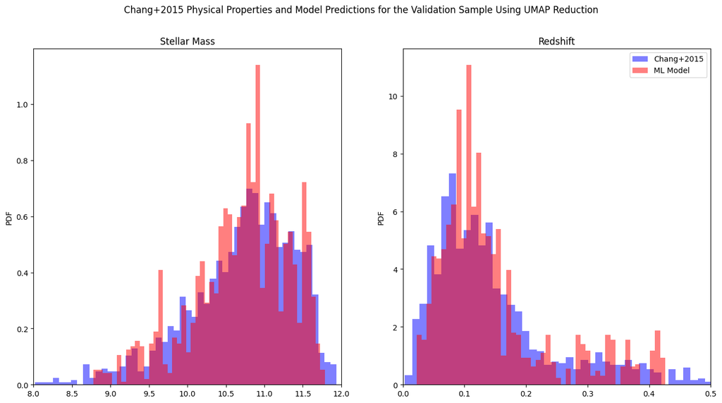

```python
# Plot distributions of real and model predictions for the test set
fig = plt.figure(figsize = (16, 8))
gs = fig.add_gridspec(1, 2, wspace = 0.2, hspace = 0.0)

# Add axes to the plot
ax1 = fig.add_subplot(gs[0, 0])
ax2 = fig.add_subplot(gs[0, 1])

# Add titles to the plot
fig.suptitle('Chang+2015 Physical Properties and Model Predictions for the Validation Sample Using UMAP Reduction')
ax1.title.set_text('Stellar Mass')
ax2.title.set_text('Redshift')

# Add the data to the plots
ax1.hist(Y_test[:, 0], bins = 50, density = True, color = 'blue', alpha = 0.5, zorder = 1)
ax1.hist(Mass_test_pred, bins = 50, density = True, color = 'red', alpha = 0.5, zorder = 2)
ax2.hist(Y_test[:, 1], bins = 50, density = True, color = 'blue', alpha = 0.5, zorder = 1, label = 'Chang+2015')
ax2.hist(Red_test_pred, bins = 50, density = True, color = 'red', alpha = 0.5, zorder = 2, label = 'ML Model')

# Add labels to the axes and a legend
ax1.set_xlim([8.0, 12.0])
ax1.set_ylabel('PDF')
ax2.set_xlim([0.0, 0.5])
ax2.set_ylabel('PDF')
ax2.legend()

plt.show()
```

The figure above shows the distribution of physical properties from Chang+2015 for our validation sample compared to the predictions from our ML model. To create this figure, our ML model was trained using data that was compressed using UMAP as opposed to the full datavector. As before, the model predictions are shown in red, while the physical properties from the output table are shown in blue.

We find that the model histograms for both stellar mass and redshift are quite similar compared to that using the uncompressed data. The biggest differences we find between the above and the uncompressed data are: (1) sharper peaks and more pronounced voids in the model predictions for the physical properties and (2) fewer model predictions at the tail ends of the distributions.

```
Results for test_sample.csv for the UMAP reduced data:

Stellar Mass:
Mean squared error: 0.49277963493826926
Accuracy Score: -0.09189503153646195


Redshift:
Mean squared error: 0.00867235227183993
Accuracy Score: -2.157847162364348
```

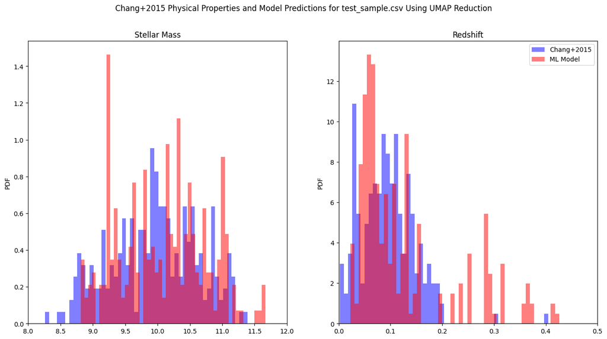

```python
# Apply UMAP transformation to our test sample
X_SAMPLE_new = reducer.transform(X_SAMPLE)

# Predict stellar masses and redshifts for our TEST SAMPLE
print('Results for test_sample.csv for the UMAP reduced data: \n')
Mass_sample_pred = DT_Mass2.predict(X_SAMPLE_new)
Red_sample_pred = DT_Redshift2.predict(X_SAMPLE_new)

# Print stellar mass accuracy and mean square error
print('Stellar Mass:')
print('Mean squared error:', mean_squared_error(Y_SAMPLE[:, 0], Mass_sample_pred))
print('Accuracy Score:', DT_Mass2.score(X_SAMPLE_new, Y_SAMPLE[:, 0]))
print('\n')

# Print redshift accuracy and mean square error
print('Redshift:')
print('Mean squared error:', mean_squared_error(Y_SAMPLE[:, 1], Red_sample_pred))
print('Accuracy Score:', DT_Redshift2.score(X_SAMPLE_new, Y_SAMPLE[:, 1]))
print('\n')

# Plot distributions of real and model predictions for the test set
fig = plt.figure(figsize = (16, 8))
gs = fig.add_gridspec(1, 2, wspace = 0.2, hspace = 0.0)

# Add axes to the plot
ax1 = fig.add_subplot(gs[0, 0])
ax2 = fig.add_subplot(gs[0, 1])

# Add titles to the plot
fig.suptitle('Chang+2015 Physical Properties and Model Predictions for test_sample.csv Using UMAP Reduction')
ax1.title.set_text('Stellar Mass')
ax2.title.set_text('Redshift')

# Add the data to the plots
ax1.hist(Y_SAMPLE[:, 0], bins = 50, density = True, color = 'blue', alpha = 0.5, zorder = 1)
ax1.hist(Mass_sample_pred, bins = 50, density = True, color = 'red', alpha = 0.5, zorder = 2)
ax2.hist(Y_SAMPLE[:, 1], bins = 50, density = True, color = 'blue', alpha = 0.5, zorder = 1, label = 'Chang+2015')
ax2.hist(Red_sample_pred, bins = 50, density = True, color = 'red', alpha = 0.5, zorder = 2, label = 'ML Model')

# Add labels to the axes
ax1.set_xlim([8.0, 12.0])
ax1.set_ylabel('PDF')
ax2.set_xlim([0.0, 0.5])
ax2.set_ylabel('PDF')

# Add a legend
ax2.legend()

plt.show()
```

This implies that there must be differences in the output physical properties we are trying to model between samples. If we look at the stellar mass and redshift distributions from Chang+2015, the training set the model is fit against and the validation set have distributions that overlap well. In contrast, these distributions for test_sample.csv look very different from the training set.

In particular, the stellar mass distribution for test_sample.csv has an excess number of low stellar mass galaxies ($M < 10^{10} M_\odot$) and the redshift distribution does not have enough intermediate-to-high redshift targets ($z > 0.2$). This is shown in the bottom two plots below where we plot the stellar mass and redshift distributions for test_sample.csv compared to the distributions of these parameters for the closest objects in the training set. To do this, we take each object in test_sample.csv, get its UMAP compression, and find its closest counterpart in the training set by Euclidean distance.

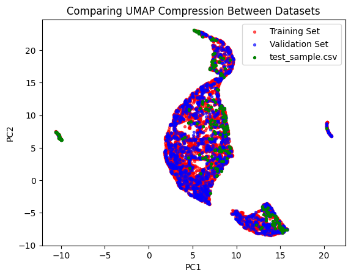

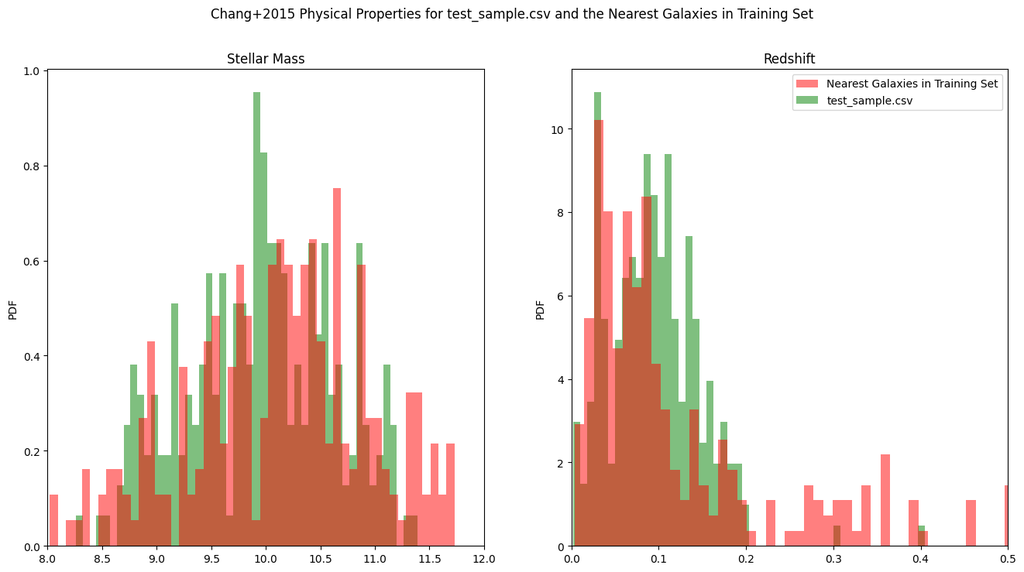

```python
# Find the objects in test_sample.csv that are closest
# to the training set by UMAP compression
near_SM = np.zeros(X_SAMPLE_new.shape[0])
near_R = np.zeros(X_SAMPLE_new.shape[0])
for i in range(0, X_SAMPLE_new.shape[0]):

    # Calculate the distance between each point
    D = np.sqrt( (X_train[:, 0] - X_SAMPLE_new[i, 0])**2 + (X_train[:, 1] - X_SAMPLE_new[i, 1])**2 )

    # Find the position of minimum distance
    min_idx = np.where(D == min(D))[0][0]

    # Record the stellar mass and redshift of the
    # nearest UMAP coordinates
    near_SM[i] = Y_train[min_idx, 0]
    near_R[i] = Y_train[min_idx, 1]

# End of for loop

# Plot comparison of UMAP between training, validation,
# and test_sample.csv sets
plt.title('Comparing UMAP Compression Between Datasets')
plt.scatter(X_train[:, 0], X_train[:, 1], s = 8, marker = 'o', color = 'red', alpha = 0.6, label = 'Training Set')
plt.scatter(X_test[:, 0], X_test[:, 1], s = 8, marker = 'o', color = 'blue', alpha = 0.6, label = 'Validation Set')
plt.scatter(X_SAMPLE_new[:, 0], X_SAMPLE_new[:, 1], s = 8, marker = 'o', color = 'green', alpha = 1.0, label = 'test_sample.csv')
plt.xlabel('PC1')
plt.ylabel('PC2')
plt.legend()
plt.show()

# Plot distributions of real and model predictions for the test set
fig = plt.figure(figsize = (16, 8))
gs = fig.add_gridspec(1, 2, wspace = 0.2, hspace = 0.0)

# Add axes to the plot
ax1 = fig.add_subplot(gs[0, 0])
ax2 = fig.add_subplot(gs[0, 1])

# Add titles to the plot
fig.suptitle('Chang+2015 Physical Properties for test_sample.csv and the Nearest Galaxies in Training Set')
ax1.title.set_text('Stellar Mass')
ax2.title.set_text('Redshift')

# Add the data to the plots
ax1.hist(near_SM, bins = 50, density = True, color = 'red', alpha = 0.5, zorder = 2)
ax1.hist(Y_SAMPLE[:, 0], bins = 50, density = True, color = 'green', alpha = 0.5, zorder = 1)
ax2.hist(near_R, bins = 50, density = True, color = 'red', alpha = 0.5, zorder = 2, label = 'Nearest Galaxies in Training Set')
ax2.hist(Y_SAMPLE[:, 1], bins = 50, density = True, color = 'green', alpha = 0.5, zorder = 1, label = 'test_sample.csv')

# Add labels to the axes and a legend
ax1.set_xlim([8.0, 12.0])
ax1.set_ylabel('PDF')
ax2.set_xlim([0.0, 0.5])
ax2.set_ylabel('PDF')
ax2.legend()

plt.show()
```

#### Question 6 [bonus]

Think back to the results you got from clustering. Does the model work equally well for galaxies in the different clusters?

```python
# Skipped
```